# IESB EAD - Probabilidade e estatística

## 11.Elabore um gráfico boxplot mostrando a duração das reclamações por região.

```python
dfs.info()
```

```
<class 'pandas.core.frame.DataFrame'>
RangeIndex: 203486 entries, 0 to 203485
Data columns (total 23 columns):
 #   Column                 Non-Null Count   Dtype
---  ------                 --------------   -----
 0   ï»¿AnoCalendario       203486 non-null  int64
 1   DataArquivamento       203486 non-null  object
 2   DataAbertura           203486 non-null  datetime64[ns]
 3   CodigoRegiao           203486 non-null  int64
 4   Regiao                 203486 non-null  object
 5   UF                     203486 non-null  object
 6   strRazaoSocial         203483 non-null  object
 7   strNomeFantasia        173722 non-null  object
 8   Tipo                   203486 non-null  int64
 9   NumeroCNPJ             195292 non-null  float64
 10  RadicalCNPJ            195292 non-null  float64
 11  RazaoSocialRFB         187287 non-null  object
 12  NomeFantasiaRFB        92561 non-null   object
 13  CNAEPrincipal          187287 non-null  float64
 14  DescCNAEPrincipal      185784 non-null  object
 15  Atendida               203486 non-null  object
 16  CodigoAssunto          203486 non-null  int64
 17  DescricaoAssunto       203486 non-null  object
 18  CodigoProblema         203476 non-null  float64
 19  DescricaoProblema      203476 non-null  object
 20  SexoConsumidor         203484 non-null  object
 21  FaixaEtariaConsumidor  203486 non-null  object
 22  CEPConsumidor          189400 non-null  float64
dtypes: datetime64[ns](1), float64(5), int64(4), object(13)
memory usage: 35.7+ MB
```

```python
dfs['DataArquivamento'] = dfs ['DataArquivamento'].astype('datetime64')
```

```python
dfs['DataArquivamento'].dt.day
```

```
0         17
1         15
2         16
3         18
4          9
          ..
203481    24
203482    27
203483    21
203484    16
203485    21
Name: DataArquivamento, Length: 203486, dtype: int64
```

```python
dfs['DataAbertura'].dt.day
```

```
0         29
1         18
2         29
3         21
4          7
          ..
203481     6
203482     2
203483    29
203484    19
203485    19
Name: DataAbertura, Length: 203486, dtype: int64
```

```python
dfs['Diferença']=dfs['DataArquivamento']-dfs['DataAbertura']
```

```python
dfs[dfs.Diferença.duplicated()]
```

|  | ï»¿AnoCalendario | DataArquivamento | DataAbertura | CodigoRegiao | Regiao | UF | strRazaoSocial | strNomeFantasia | Tipo | NumeroCNPJ | ... | DescCNAEPrincipal | Atendida | CodigoAssunto | DescricaoAssunto | CodigoProblema | DescricaoProblema | SexoConsumidor | FaixaEtariaConsumidor | CEPConsumidor | Diferença |
| --- | --- | --- | --- | --- | --- | --- | --- | --- | --- | --- | --- | --- | --- | --- | --- | --- | --- | --- | --- | --- | --- |
| 128 | 2016 | 2016-07-08 11:17:04 | 2014-05-09 08:45:28 | 2 | Nordeste | PI | LOJAS INSINUANTE LTDA | LOJAS INSINUANTE | 1 | 1.618283e+13 | ... | COMÉRCIO VAREJISTA ESPECIALIZADO DE ELETRODOM... | S | 96 | Televisão / Vídeo Cassete / Filmadora / Vide... | 105.0 | Produto com vício | M | Nao Informada | 64040220.0 | 791 days 02:31:36 |
| 130 | 2016 | 2016-06-17 10:39:03 | 2014-05-20 09:08:31 | 2 | Nordeste | PI | POSITIVO INFORMATICA S/A | POSITIVO INFORMATICA | 1 | 8.124374e+13 | ... | FABRICAÇÃO DE EQUIPAMENTOS DE INFORMÁTICA | S | 102 | Microcomputador / Produtos de Informática | 105.0 | Produto com vício | F | entre 41 a 50 anos | NaN | 759 days 01:30:32 |
| 134 | 2016 | 2016-07-05 10:15:15 | 2014-02-11 11:46:14 | 2 | Nordeste | PI | POSITIVO INFORMATICA S/A | POSITIVO INFORMATICA | 1 | 8.124374e+13 | ... | FABRICAÇÃO DE EQUIPAMENTOS DE INFORMÁTICA | S | 102 | Microcomputador / Produtos de Informática | 105.0 | Produto com vício | F | Nao Informada | 64360000.0 | 874 days 22:29:01 |
| 139 | 2016 | 2016-11-09 12:12:58 | 2016-10-11 11:12:53 | 4 | Sul | SC | MASTERCELL | NaN | 1 | 2.455036e+12 | ... | NaN | N | 88 | Acessório para Aparelho Eletrônico/Pilha/ElÃ... | 105.0 | Produto com vício | M | Nao Informada | 89223130.0 | 29 days 01:00:05 |
| 142 | 2016 | 2016-11-25 16:12:06 | 2016-10-31 15:19:54 | 4 | Sul | SC | ALLTECH INFORMATICA E TECNOLOGIA LTDA - ME | NaN | 1 | 1.975691e+12 | ... | NaN | S | 88 | Acessório para Aparelho Eletrônico/Pilha/ElÃ... | 107.0 | Não entrega/demora na entrega do produto | M | entre 31 a 40 anos | 89221006.0 | 25 days 00:52:12 |
| ... | ... | ... | ... | ... | ... | ... | ... | ... | ... | ... | ... | ... | ... | ... | ... | ... | ... | ... | ... | ... | ... |
| 203418 | 2016 | 2016-07-12 08:54:32 | 2016-06-20 11:38:30 | 2 | Nordeste | PE | CNOVA COMÉRCIO ELETRONICO S.A | EXTRA.COM CASASBAHIA.COM PONTOFRIO.COM EHUB.CO... | 1 | 9.358108e+12 | ... | LOJAS DE DEPARTAMENTOS OU MAGAZINES | S | 288 | Máquinas e Equipamentos | 105.0 | Produto com vício | M | entre 21 a 30 anos | 50610370.0 | 21 days 21:16:02 |
| 203419 | 2016 | 2016-07-12 08:54:32 | 2016-06-20 11:38:30 | 2 | Nordeste | PE | L. S. DE LIRA ELETRONICA | DIGITAL CENTER | 1 | 8.742286e+12 | ... | REPARAÇÃO E MANUTENÇÃO DE EQUIPAMENTOS ELE... | S | 288 | Máquinas e Equipamentos | 105.0 | Produto com vício | M | entre 21 a 30 anos | 50610370.0 | 21 days 21:16:02 |
| 203438 | 2016 | 2016-11-09 13:23:55 | 2016-08-01 08:46:29 | 3 | Sudeste | SP | UNIDADE EDUCACIONAL DE ENSINO MEDIO ALCANCE LTDA | NaN | 1 | 8.771977e+12 | ... | ENSINO MÉDIO | N | 233 | Escola ( Pré, 1º, 2º Graus e Superior ) | 194.0 | Cobrança indevida/abusiva | M | entre 31 a 40 anos | 4859070.0 | 100 days 04:37:26 |
| 203452 | 2016 | 2016-05-31 10:28:22 | 2016-04-25 10:40:31 | 3 | Sudeste | SP | MAX PLUS EQUIPAMENTOS DE SEGURANÇA LTDA - EPP | MAX LINE | 1 | 1.818972e+13 | ... | COMÉRCIO VAREJISTA DE OUTROS ARTIGOS DE USO D... | N | 96 | Televisão / Vídeo Cassete / Filmadora / Vide... | 111.0 | Venda enganosa | M | Nao Informada | 13457074.0 | 35 days 23:47:51 |
| 203463 | 2016 | 2016-08-25 15:10:44 | 2016-07-12 13:43:29 | 3 | Sudeste | SP | EMBRACON ADMINISTRADORA DE CONSORCIO LTDA | NaN | 1 | 5.811381e+13 | ... | ADMINISTRAÇÃO DE CONSÓRCIOS PARA AQUISIÇÃ... | N | 79 | Seguro | 62.0 | Não pagamento de indenização | F | Nao Informada | NaN | 44 days 01:27:15 |

35870 rows × 24 columns

```python
dfs[~dfs.Diferença.duplicated()]
```

|  | ï»¿AnoCalendario | DataArquivamento | DataAbertura | CodigoRegiao | Regiao | UF | strRazaoSocial | strNomeFantasia | Tipo | NumeroCNPJ | ... | DescCNAEPrincipal | Atendida | CodigoAssunto | DescricaoAssunto | CodigoProblema | DescricaoProblema | SexoConsumidor | FaixaEtariaConsumidor | CEPConsumidor | Diferença |
| --- | --- | --- | --- | --- | --- | --- | --- | --- | --- | --- | --- | --- | --- | --- | --- | --- | --- | --- | --- | --- | --- |
| 0 | 2016 | 2016-02-17 13:43:08 | 2015-10-29 10:59:59 | 2 | Nordeste | PE | CVC BRASIL OPERADORA E AGENCIA DE VIAGENS S.A. | CVC | 1 | 1.076026e+13 | ... | AGÊNCIAS DE VIAGENS | S | 276 | Agências e Operadoras de viagens (pacotes tur... | 205.0 | Consulta Sobre Serviços (Pesquisa, cartilha, ... | M | entre 61 a 70 anos | 52061540.0 | 111 days 02:43:09 |
| 1 | 2016 | 2016-12-15 18:11:35 | 2016-11-18 14:52:22 | 2 | Nordeste | PE | GIORGIO ARMANI BRASIL COMERCIO | EMPORIO ARMANI | 1 | 1.318050e+13 | ... | NaN | N | 132 | Vestuário ( Calçado / Roupa ) | 105.0 | Produto com vício | F | entre 31 a 40 anos | 51010140.0 | 27 days 03:19:13 |
| 2 | 2016 | 2016-09-16 09:01:46 | 2016-06-29 13:58:35 | 2 | Nordeste | PE | COMPANHIA ENERGETICA DE PERNAMBUCO | CELPE | 1 | 1.083593e+13 | ... | DISTRIBUIÇÃO DE ENERGIA ELÉTRICA | S | 185 | Energia Elétrica | 134.0 | Cobrança indevida/abusiva | F | entre 51 a 60 anos | 53060600.0 | 78 days 19:03:11 |
| 3 | 2016 | 2016-02-18 13:30:30 | 2016-01-21 12:23:51 | 2 | Nordeste | PE | MOURA DUBEUX | MOURA DUBEUX | 1 | 1.204963e+13 | ... | CONSTRUÇÃO DE EDIFÍCIOS | S | 82 | Incorporação ( Construtoras e Incorporadoras ) | 88.0 | Não entrega do contrato | M | entre 51 a 60 anos | 53090220.0 | 28 days 01:06:39 |
| 4 | 2016 | 2016-11-09 14:20:36 | 2016-10-07 16:39:59 | 2 | Nordeste | PE | ASSOCIAÇÃO UNIFICADA PAULISTA DE ENSINO RENO... | UNIP | 1 | NaN | ... | NaN | S | 233 | Escola ( Pré, 1º, 2º Graus e Superior ) | 199.0 | Documentos: não fornecimento (escolares, reci... | F | entre 21 a 30 anos | 53437100.0 | 32 days 21:40:37 |
| ... | ... | ... | ... | ... | ... | ... | ... | ... | ... | ... | ... | ... | ... | ... | ... | ... | ... | ... | ... | ... | ... |
| 203481 | 2016 | 2016-08-24 10:19:29 | 2016-05-06 11:21:45 | 3 | Sudeste | SP | OI MÓVEL S/A | OI CELULAR/OI TV | 1 | 5.423963e+12 | ... | TELEFONIA MÓVEL CELULAR | S | 187 | Telefonia Celular | 143.0 | Contrato - Rescisão/alteração unilateral | M | entre 51 a 60 anos | 4763310.0 | 109 days 22:57:44 |
| 203482 | 2016 | 2016-10-27 09:19:09 | 2016-05-02 15:28:57 | 3 | Sudeste | SP | ELETROPAULO METROPOLITANA ELETRICIDADE DE S PAULO | ELETROPAULO METROPOLITANA | 1 | 6.169523e+13 | ... | DISTRIBUIÇÃO DE ENERGIA ELÉTRICA | N | 185 | Energia Elétrica | 134.0 | Cobrança indevida/abusiva | M | entre 41 a 50 anos | 4846010.0 | 177 days 17:50:12 |
| 203483 | 2016 | 2016-09-21 09:11:21 | 2016-04-29 16:20:30 | 3 | Sudeste | SP | AUTO ESCOLA ULTRA FACIL LTDA EPP | NaN | 1 | 1.802559e+13 | ... | FORMAÇÃO DE CONDUTORES | S | 264 | Automóvel - Locação / Assistência Automobi... | 185.0 | Serviço não concluído /Fornecimento parcial | F | entre 21 a 30 anos | 5731090.0 | 144 days 16:50:51 |
| 203484 | 2016 | 2016-08-16 10:58:52 | 2016-04-19 07:58:16 | 3 | Sudeste | SP | FINANCEIRA ITAU CBD S/A CRÉDITO FINANCIAMENTO... | FIC FINANCEIRA ITAÚ CBD / FIT | 1 | 6.881898e+12 | ... | SOCIEDADES DE CRÉDITO, FINANCIAMENTO E INVEST... | S | 53 | Banco comercial | 28.0 | Cobrança indevida/abusiva | F | entre 21 a 30 anos | 4438250.0 | 119 days 03:00:36 |
| 203485 | 2016 | 2016-09-21 09:44:57 | 2016-04-19 08:42:27 | 3 | Sudeste | SP | VALBET CENTRO AUTOMOTIVO LTDA ME | NaN | 1 | 2.035944e+13 | ... | NaN | S | 250 | Oficinas ( Mecânica, Funilaria, Auto-Elétric... | 183.0 | Vicio de qualidade (mal executado, inadequado,... | M | entre 51 a 60 anos | 4470261.0 | 155 days 01:02:30 |

167616 rows × 24 columns

```python
dfs[~dfs.Diferença.duplicated()]['Diferença'].value_counts()
```

```
111 days 02:43:09    1
90 days 22:49:33     1
150 days 16:49:40    1
197 days 01:22:37    1
327 days 22:06:40    1
                    ..
60 days 17:05:42     1
175 days 01:48:03    1
57 days 06:50:09     1
87 days 21:59:36     1
155 days 01:02:30    1
Name: Diferença, Length: 167616, dtype: int64
```

```python
dfs[~dfs.Diferença.duplicated()].describe()
```

|  | ï»¿AnoCalendario | CodigoRegiao | Tipo | NumeroCNPJ | RadicalCNPJ | CNAEPrincipal | CodigoAssunto | CodigoProblema | CEPConsumidor | Diferença |
| --- | --- | --- | --- | --- | --- | --- | --- | --- | --- | --- |
| count | 167616.0 | 167616.000000 | 167616.000000 | 1.618130e+05 | 1.618130e+05 | 1.550120e+05 | 167616.000000 | 167606.000000 | 1.562120e+05 | 167616 |
| mean | 2016.0 | 2.905164 | 0.996880 | 2.315880e+13 | 1.166777e+08 | 5.610674e+06 | 142.984638 | 123.016849 | 4.978683e+07 | 238 days 02:09:17.607710480 |
| std | 0.0 | 1.154209 | 0.055772 | 2.505512e+13 | 2.418607e+09 | 1.575485e+06 | 71.870089 | 60.954373 | 2.772248e+07 | 433 days 06:07:54.893449344 |
| min | 2016.0 | 1.000000 | 0.000000 | 1.910000e+02 | 0.000000e+00 | 1.156000e+05 | 1.000000 | 1.000000 | 0.000000e+00 | 0 days 00:00:14 |
| 25% | 2016.0 | 2.000000 | 1.000000 | 4.206050e+12 | 4.206050e+06 | 4.713001e+06 | 89.000000 | 105.000000 | 2.914040e+07 | 41 days 20:38:03 |
| 50% | 2016.0 | 3.000000 | 1.000000 | 1.077276e+13 | 1.083593e+07 | 6.120501e+06 | 122.000000 | 113.000000 | 5.502330e+07 | 85 days 01:08:51 |
| 75% | 2016.0 | 4.000000 | 1.000000 | 3.873365e+13 | 4.043254e+07 | 6.423900e+06 | 187.000000 | 148.000000 | 7.702168e+07 | 200 days 04:21:09 |
| max | 2016.0 | 5.000000 | 1.000000 | 9.840807e+13 | 9.965391e+10 | 9.700500e+06 | 288.000000 | 262.000000 | 9.969800e+07 | 3975 days 22:39:06 |

```python
dfs_unique = dfs[~dfs.Diferença.duplicated()]
```

```python
dfs['Diferença'].nunique()
```

```
167616
```

[figure not shown]

```python
dfs_groupby=dfs.groupby(['DataArquivamento','DataAbertura','Diferença']).count()
dfs_groupby.boxplot(by='Regiao',column='UF')
```

## Elabore um gráfico boxplot mostrando a quantidade de reclamações por Região.

Explicando o código: Usei o groupby, juntando a região e uf, pra verificar se conseguiria os números para plotar o boxplot. Consegui os valores de máx,med,min. (.count()) para contabilizar isso. (.reset_index()) para ajustar as informações que estavam em nível diferente (Regiao e UF). E com isso tudo, fiz a minha variável. Usei a variável, coloquei (.boxplot) e usei a DataAbertura como coluna, já que agrupei o box com a Região. Figsize para ajustas o tamanho do box.

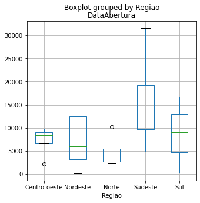

```python
dfs_agrupado = dfs.groupby(["Regiao", "UF"]).count().reset_index()
dfs_agrupado.boxplot(by="Regiao",column = "DataAbertura", figsize = (5,5))
```

## 12.É possível afirmar que existe correlação entre o número de reclamações E o número de habitantes por Estado? Elabore um gráfico de dispersão e calcule o índice de correlação destes dois fatores.

Resposta: Não é possível afirmar, pois tem algumas regiões na qual não temos o valor de reclamação por UF. Gráfico não ficou linear também.

```python
data = {'HNorte': [1787279,816687,4001667,514229,8272724,782295,1532902,0,0],
        'HNordeste': [6954036,3212180,8963663,3474998,3999415,9410336,3358963,2265779,15276566],
        'HSudeste': [20997560,3973697,16635996,44749699,0,0,0,0,0],
        'HSul': [11242720,6910553,11286500,0,0,0,0,0,0],
        'HCentro': [2682386,3305531,6695855,2977216,0,0,0,0,0],
        'RNorte':[3922,0,2318,0,2730,0,10232,0,0],
        'RNordeste':[3597,2189,10833,4443,7464,20175,191,0,17519],
        'RSudeste':[15159,11383,4884,31548,0,0,0,0,0],
        'RSul':[9132,16718,263,0,0,0,0,0,0],
        'RCentro':[9789,8770,8060,2167,0,0,0,0,0],
        }

df = pd.DataFrame(data,columns=['HNorte','HNordeste','HSudeste','HSul','HCentro',
                                'RNorte','RNordeste','RSudeste','RSul','RCentro'])
print (df)
```

```
    HNorte  HNordeste  HSudeste      HSul  HCentro  RNorte  RNordeste  \
0  1787279    6954036  20997560  11242720  2682386    3922       3597
1   816687    3212180   3973697   6910553  3305531       0       2189
2  4001667    8963663  16635996  11286500  6695855    2318      10833
3   514229    3474998  44749699         0  2977216       0       4443
4  8272724    3999415         0         0        0    2730       7464
5   782295    9410336         0         0        0       0      20175
6  1532902    3358963         0         0        0   10232        191
7        0    2265779         0         0        0       0          0
8        0   15276566         0         0        0       0      17519

   RSudeste   RSul  RCentro
0     15159   9132     9789
1     11383  16718     8770
2      4884    263     8060
3     31548      0     2167
4         0      0        0
5         0      0        0
6         0      0        0
7         0      0        0
8         0      0        0
```

```python
df.corr(method='pearson')
```

|  | HNorte | HNordeste | HSudeste | HSul | HCentro | RNorte | RNordeste | RSudeste | RSul | RCentro |
| --- | --- | --- | --- | --- | --- | --- | --- | --- | --- | --- |
| HNorte | 1.000000 | -0.150598 | -0.120275 | 0.120315 | 0.099581 | 0.232338 | 0.006428 | -0.224402 | -0.159483 | 0.015039 |
| HNordeste | -0.150598 | 1.000000 | -0.157010 | 0.088952 | 0.007409 | -0.242912 | 0.845493 | -0.278443 | -0.222952 | -0.040712 |
| HSudeste | -0.120275 | -0.157010 | 1.000000 | 0.269807 | 0.561837 | -0.151243 | -0.191097 | 0.936314 | 0.016210 | 0.364624 |
| HSul | 0.120315 | 0.088952 | 0.269807 | 1.000000 | 0.808700 | 0.054197 | -0.131950 | 0.223875 | 0.559145 | 0.953420 |
| HCentro | 0.099581 | 0.007409 | 0.561837 | 0.808700 | 1.000000 | -0.115174 | -0.092805 | 0.466307 | 0.318902 | 0.801161 |
| RNorte | 0.232338 | -0.242912 | -0.151243 | 0.054197 | -0.115174 | 1.000000 | -0.401000 | -0.216541 | -0.118706 | -0.036926 |
| RNordeste | 0.006428 | 0.845493 | -0.191097 | -0.131950 | -0.092805 | -0.401000 | 1.000000 | -0.301040 | -0.340836 | -0.238929 |
| RSudeste | -0.224402 | -0.278443 | 0.936314 | 0.223875 | 0.466307 | -0.216541 | -0.301040 | 1.000000 | 0.283828 | 0.411556 |
| RSul | -0.159483 | -0.222952 | 0.016210 | 0.559145 | 0.318902 | -0.118706 | -0.340836 | 0.283828 | 1.000000 | 0.744103 |
| RCentro | 0.015039 | -0.040712 | 0.364624 | 0.953420 | 0.801161 | -0.036926 | -0.238929 | 0.411556 | 0.744103 | 1.000000 |

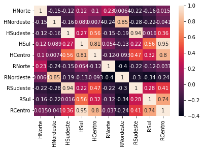

```python
sns.heatmap(df.corr(), annot= True)
```

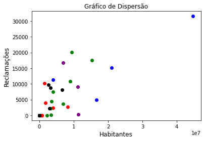

```python
#Descrição: Habitantes e Reclamações NORTE (Vermelho); Nordeste (Verde); Sudeste(Azul); Sul (Roxo); Centro(Preto)
plt.scatter(df['HNorte'],df['RNorte'],  color='red')
plt.scatter(df['HNordeste'],df['RNordeste'],  color='green')
plt.scatter(df['HSudeste'],df['RSudeste'],  color='blue')
plt.scatter(df['HSul'],df['RSul'],  color='purple')
plt.scatter(df['HCentro'],df['RCentro'],  color='black')
plt.title('Gráfico de Dispersão')
plt.ylabel('Reclamações', fontsize=12)
plt.xlabel('Habitantes', fontsize=12)
```

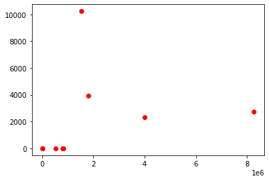

```python
plt.scatter(df['HNorte'],df['RNorte'],  color='red')
```

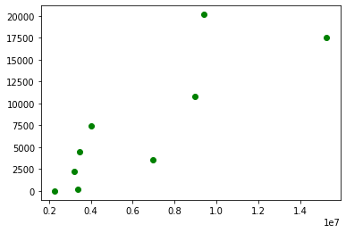

```python
plt.scatter(df['HNordeste'],df['RNordeste'],  color='green')
```

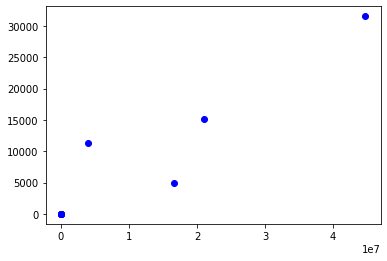

```python
plt.scatter(df['HSudeste'],df['RSudeste'],  color='blue')
```

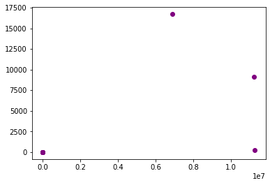

```python
plt.scatter(df['HSul'],df['RSul'],  color='purple')
```

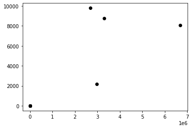

```python
plt.scatter(df['HCentro'],df['RCentro'],  color='black')
```